# Human Activity Recognition using Weight Lifting Exercises Dataset

DRManiar

9/26/2020

## Executive Summary

The objective of this project is to use machine learning (ML) methods to recognize human activity using the weight lifting exercise dataset and to predict the manner (i.e., how well) in which the exercises were performed. The dataset is collected using personal wearable devices such as Jawbone Up, Nike FuelBand, and Fitbit. To speed up the process we will use parallel processing.

```r
library(parallel)
library(doParallel)
cluster <- makeCluster(detectCores() - 1) # convention to leave 1 core for OS
registerDoParallel(cluster)
```

## Dataset Exploration

The *pml-training.csv* and *pml-testing.csv* files provided are loaded and the *pml-training.csv* file is explored to understand the data. The data for this project come from this source: http://groupware.les.inf.puc-rio.br/har.

```r
training <- read.csv("pml-training.csv")
dim(training)
```

```
## [1] 19622   160
```

```r
table(training$classe)
```

```
##
##    A    B    C    D    E
## 5580 3797 3422 3216 3607
```

The “classe” variable in the training set identifies five ways in which Unilateral Dumbbell Biceps Curl were performed: exactly according to the specification (Class A), throwing the elbows to the front (Class B), lifting the dumbbell only halfway (Class C), lowering the dumbbell only halfway (Class D) and throwing the hips to the front (Class E). So this variable is the outcome we would like predict. Now, we are going to select the predictors.

Out of 19622 rows, many rows contain **NA** for many columns, so we will remove those columns from the dataset. Also, several columns contains blank character and we will remove those columns as well. Finally, the first seven columns contain general information for each measurement (i.e., row) so they will be removed too. The “classe” variable is changed to a factor variable.

```r
nnas <- sum(is.na(training$X))
for (i in 2:ncol(training)){
    nnas <- c(nnas, sum(is.na(training[,i])))
}
#
scols <- c()
for (i in 1:ncol(training)){
    if (nnas[i]==0) scols <- c(scols,i)
}
train2 <- training[,scols]
rmcol <- c(1:7,
           grep("^kurtosis|^skewness|^max|^min|^amplitude", colnames(train2)))
train3 <- train2[,-rmcol]
train3$classe <- factor(train3$classe)
dim(train3)
```

```
## [1] 19622    53
```

The removal of columns reduced the number of columns from 160 to 53. So Now we will use the first 52 columns as predictors for the “classe” variable.

The “yaw_belt” variable is plotted for each measurement using “classe” as color.

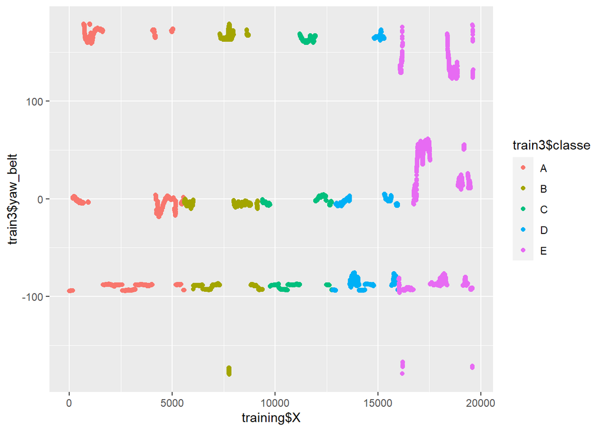

```r
library(ggplot2)
qplot(training$X,train3$yaw_belt,color=train3$classe)
```

Now, let’s remove the unwanted columns from the test dataset.

```r
testing <- read.csv("pml-testing.csv")
test2 <- testing[,scols]
test3 <- test2[,-rmcol]
```

## Use of ML Methods

In this section, we will apply machine learning (ML) methods such as rpart, boosting (gbm), linear discriminant analysis (lda), and random forest (rf). We will use default parameters for cross validation for most methods.

### **rpart** Method

```r
library(caret)
fitControl <- trainControl(method = "cv", number = 5, allowParallel = TRUE)
modFitRP <- train(classe~., data=train3, method="rpart", trControl = fitControl)
cmRP <- confusionMatrix(train3$classe, predict(modFitRP, train3))
round(prop.table(cmRP$table,2),2)
```

```
##           Reference
## Prediction    A    B    C D    E
##          A 0.50 0.03 0.08   0.01
##          B 0.15 0.51 0.18   0.00
##          C 0.16 0.04 0.33   0.00
##          D 0.14 0.22 0.23   0.00
##          E 0.05 0.19 0.18   0.99
```

```r
round(cmRP$overall[1],2)
```

```
## Accuracy
##      0.5
```

```r
predRP <- predict(modFitRP, test3)
```

The accuracy of the **rpart** model is about 50%. This is evident from the tree image below.

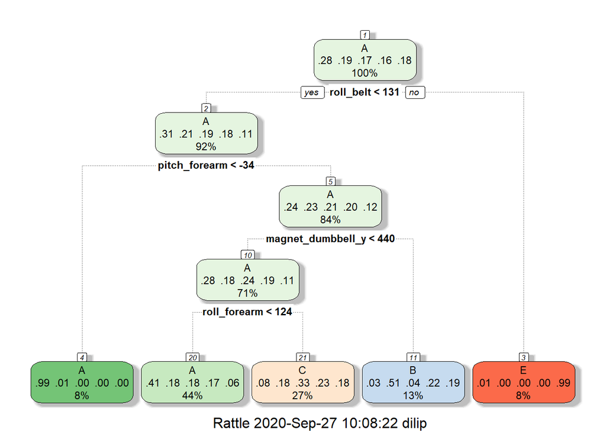

```r
library(rattle)
fancyRpartPlot(modFitRP$finalModel)
```

### Other ML Methods

The boosting (gmb), linear discriminant analysis (lda), and random forest (rf) methods are used in a similar way as use of the rpart method above.

```r
modFitGBM <- train(classe~., data=train3, method="gbm", verbose = FALSE,
                   trControl = fitControl)
cmGBM <- confusionMatrix(train3$classe, predict(modFitGBM, train3))
round(prop.table(cmGBM$table,2),2)
```

```
##           Reference
## Prediction    A    B    C    D    E
##          A 0.98 0.01 0.00 0.00 0.00
##          B 0.01 0.96 0.02 0.00 0.00
##          C 0.00 0.02 0.94 0.01 0.00
##          D 0.00 0.00 0.03 0.98 0.00
##          E 0.00 0.01 0.01 0.01 0.99
```

```r
round(cmGBM$overall[1],2)
```

```
## Accuracy
##     0.97
```

```r
predGBM <- predict(modFitGBM, test3)
```

```r
modFitLDA <- train(classe~., data=train3, method="lda", trControl = fitControl)
cmLDA <- confusionMatrix(train3$classe, predict(modFitLDA, train3))
round(prop.table(cmLDA$table,2),2)
```

```
##           Reference
## Prediction    A    B    C    D    E
##          A 0.79 0.03 0.12 0.12 0.01
##          B 0.10 0.67 0.12 0.04 0.07
##          C 0.06 0.09 0.58 0.11 0.03
##          D 0.03 0.04 0.10 0.64 0.05
##          E 0.02 0.17 0.08 0.09 0.84
```

```r
round(cmLDA$overall[1],2)
```

```
## Accuracy
##      0.7
```

```r
predLDA <- predict(modFitLDA, test3)
```

```r
modFitRF <- train(classe~., data=train3, method="rf", importance=TRUE,
                  trControl = fitControl)
cmRF <- confusionMatrix(train3$classe, predict(modFitRF,train3))
round(prop.table(cmRF$table,2),2)
```

```
##           Reference
## Prediction A B C D E
##          A 1 0 0 0 0
##          B 0 1 0 0 0
##          C 0 0 1 0 0
##          D 0 0 0 1 0
##          E 0 0 0 0 1
```

```r
round(cmRF$overall[1],2)
```

```
## Accuracy
##        1
```

```r
predRF <- predict(modFitRF, test3)
```

The above method shows that the random forest method is 100% accurate (or 0% in sample error) and boosting is about 97% accurate (or 3% in sample error). However, the out of sample error is expected to be higher than the in sample error. The lda and rpart methods perform poorly.

## Results

Accuracy for each model is provided below.

```r
Maccuracy <- data.frame("rpart" = round(cmRP$overall[1],2),
                        "lda" = round(cmLDA$overall[1],2),
                        "gbm" = round(cmGBM$overall[1],2),
                        "rf" = round(cmRF$overall[1],2))
Maccuracy
```

```
##          rpart lda  gbm rf
## Accuracy   0.5 0.7 0.97  1
```

The predictions for the test dataset from each model are provided below.

```r
predDF <- data.frame("rpart" = predRP,
                     "lds" = predLDA,
                     "gbm" = predGBM,
                     "rf" = predRF)
predDF
```

```
##    rpart lds gbm rf
## 1      C   B   B  B
## 2      A   A   A  A
## 3      C   B   B  B
## 4      A   C   A  A
## 5      A   C   A  A
## 6      C   E   E  E
## 7      C   D   D  D
## 8      A   D   B  B
## 9      A   A   A  A
## 10     A   A   A  A
## 11     C   D   B  B
## 12     C   A   C  C
## 13     C   B   B  B
## 14     A   A   A  A
## 15     C   E   E  E
## 16     A   A   E  E
## 17     A   A   A  A
## 18     A   B   B  B
## 19     A   B   B  B
## 20     C   B   B  B
```

So overall, the random forest method seems to be most accurate and the important predictors are plotted below. However, the random forest method takes a long time to run compared to the other methods.

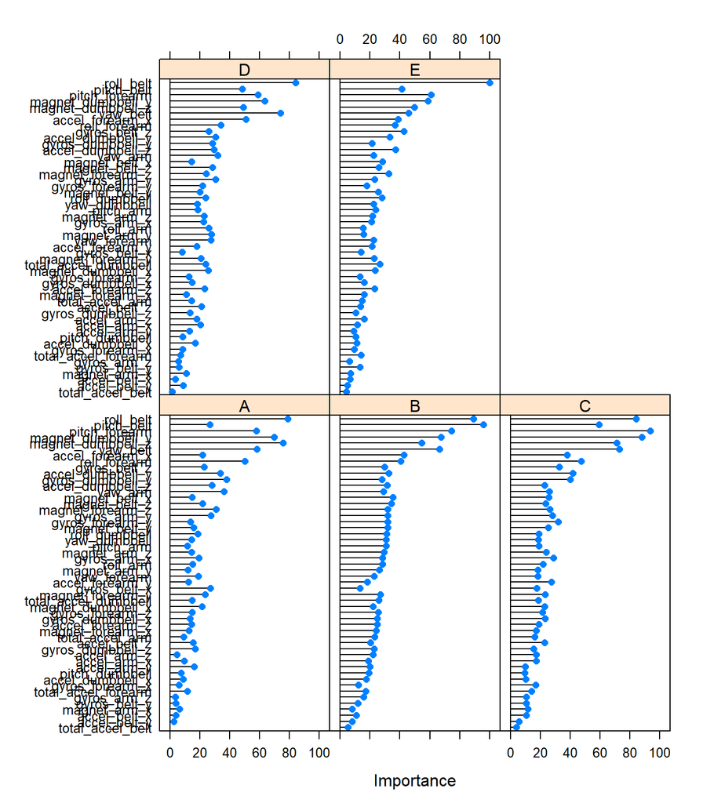

```r
plot(varImp(modFitRF))
```

```r
stopCluster(cluster)
registerDoSEQ()
```